# 2024 NH3-loss Statistical Models, outdoor only - cube root

## Model A_Irrigation

Irrigation was modeled as a binomial variable due to heavy zero-inflation in the data.

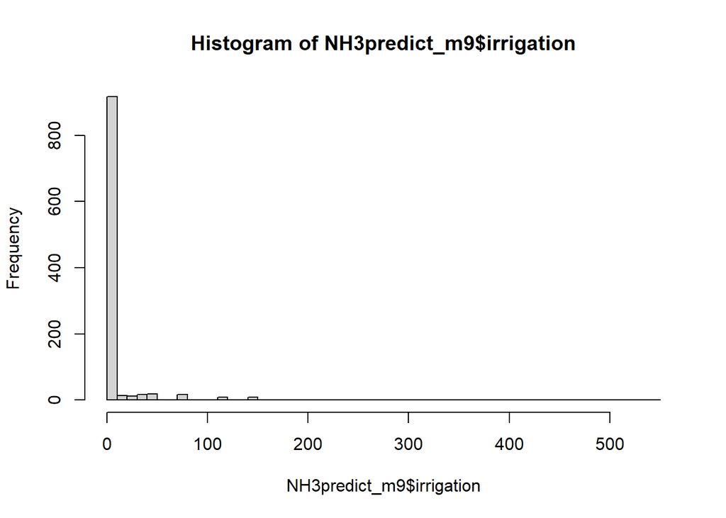

The number of observations in total in each category can be seen below:

```
##   irrigation_cat   N
## 1              0 898
## 2              1 113
```

```r
# Model
m9_lm <- lm(sign(NH3loss) * abs(NH3loss) ^ (1/3) ~ irrigation_cat + offset(M1_fit),
            weights=Weight,
            data=NH3predict_m9)
```

The check for normality and heteroscedasticity of errors can be seen below:

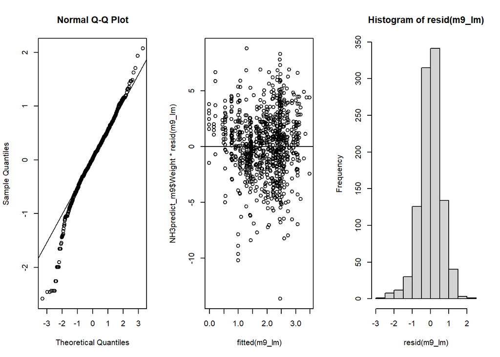

There was no effect of irrigation on NH3-loss (F(1, 1009) =0.53, p = 0.466).

```
##
## Call:
## lm(formula = sign(NH3loss) * abs(NH3loss)^(1/3) ~ irrigation_cat +
##     offset(M1_fit), data = NH3predict_m9, weights = Weight)
##
## Weighted Residuals:
##     Min      1Q  Median      3Q     Max
## -5.7876 -0.7179  0.0499  0.8188  4.2634
##
## Coefficients:
##                  Estimate Std. Error t value Pr(>|t|)
## (Intercept)      0.005127   0.019922   0.257    0.797
## irrigation_cat1 -0.043960   0.060340  -0.729    0.466
##
## Residual standard error: 1.323 on 1009 degrees of freedom
## Multiple R-squared:  0.0005258,  Adjusted R-squared:  -0.0004648
## F-statistic: 0.5308 on 1 and 1009 DF,  p-value: 0.4665
```

Adjusted R2-value of the model was -4.6^{-4}, and multiple R2 was 5.3^{-4}. The negative adjusted R2-value indicates that the amount of variation accounted for by irrigation is negligible. In practice, it explain no variation in the data.

The marginal means for NH3 loss in no-irrigation and irrigation categories can be seen below.

```
##   irrigation_cat   emmean         SE   df lower.CL upper.CL
## 1              0 1.844304 0.01992211 1009 1.805210 1.883398
## 2              1 1.800344 0.05695615 1009 1.688578 1.912110
```

```
## `height` was translated to `width`.
```

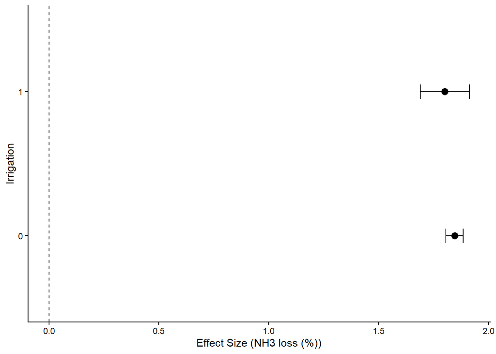

## Model A_Water input

Daily water input (mm) consists of irrigation and rainfall.

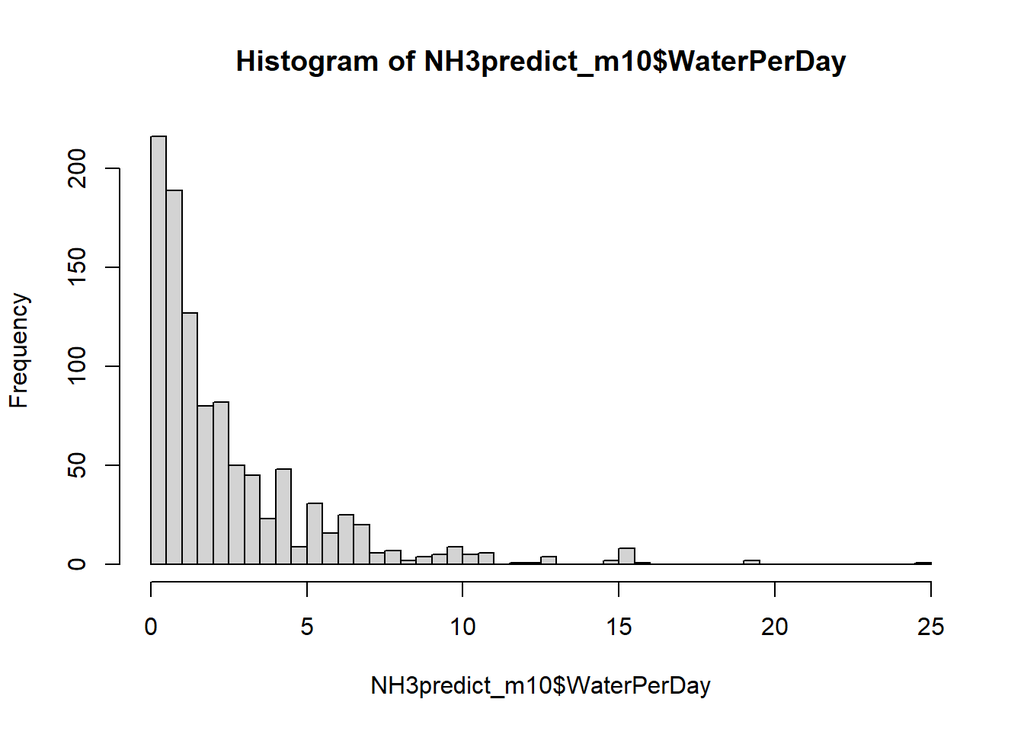

```r
#  Model
m10_lm <- lm(sign(NH3loss) * abs(NH3loss) ^ (1/3) ~ WaterPerDay + offset(M1_fit),
             weights=Weight,
             data=NH3predict_m10)
```

Heteroscedasticity and normality of erros were as below:

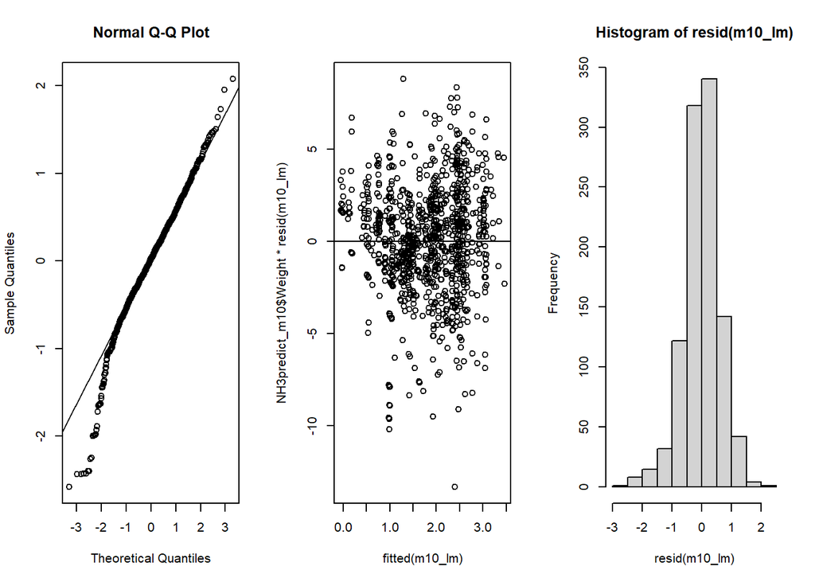

There was no effect of water input on NH3-loss (F(1, 1023) =1.84, p = 0.175).

```
##
## Call:
## lm(formula = sign(NH3loss) * abs(NH3loss)^(1/3) ~ WaterPerDay +
##     offset(M1_fit), data = NH3predict_m10, weights = Weight)
##
## Weighted Residuals:
##     Min      1Q  Median      3Q     Max
## -5.6504 -0.7649  0.0498  0.8631  4.2692
##
## Coefficients:
##              Estimate Std. Error t value Pr(>|t|)
## (Intercept)  0.014622   0.025138   0.582    0.561
## WaterPerDay -0.009023   0.006645  -1.358    0.175
##
## Residual standard error: 1.358 on 1023 degrees of freedom
## Multiple R-squared:  0.001799,   Adjusted R-squared:  0.0008232
## F-statistic: 1.844 on 1 and 1023 DF,  p-value: 0.1748
```

```
## Analysis of Variance Table
##
## Response: sign(NH3loss) * abs(NH3loss)^(1/3)
##               Df Sum Sq Mean Sq F value Pr(>F)
## WaterPerDay    1    3.4  3.3996  1.8436 0.1748
## Residuals   1023 1886.4  1.8440
```

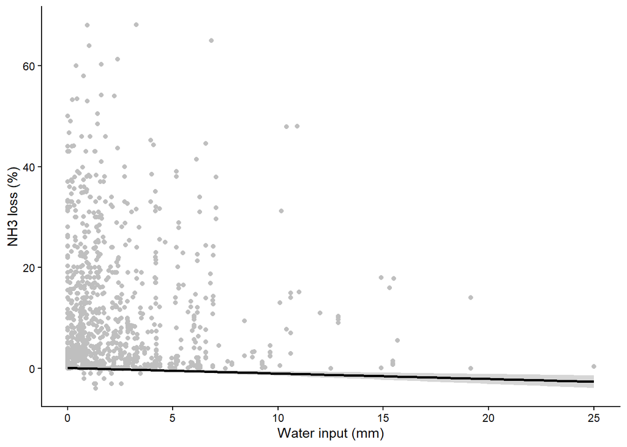

## Model A_Experiment duration

Duration of the experiment (days).

```
##    Min. 1st Qu.  Median    Mean 3rd Qu.    Max.
##     3.0    10.0    18.0    20.2    25.0   120.0
```

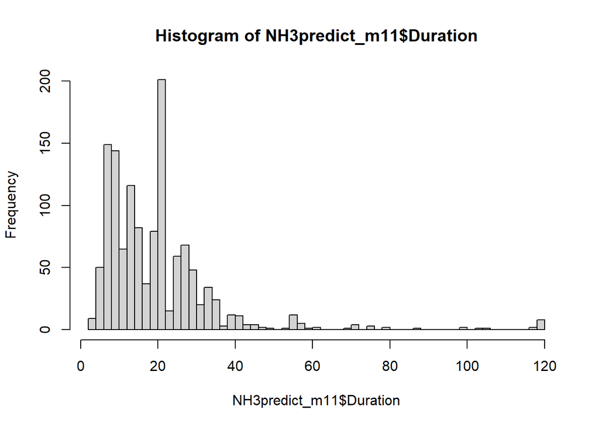

```r
#  Model
m11_lm <- lm(sign(NH3loss) * abs(NH3loss) ^ (1/3) ~ Duration + offset(M1_fit),
             weights=Weight,
             data=NH3predict_m11)
```

Heteroscedasticity and normality of erros were as below:

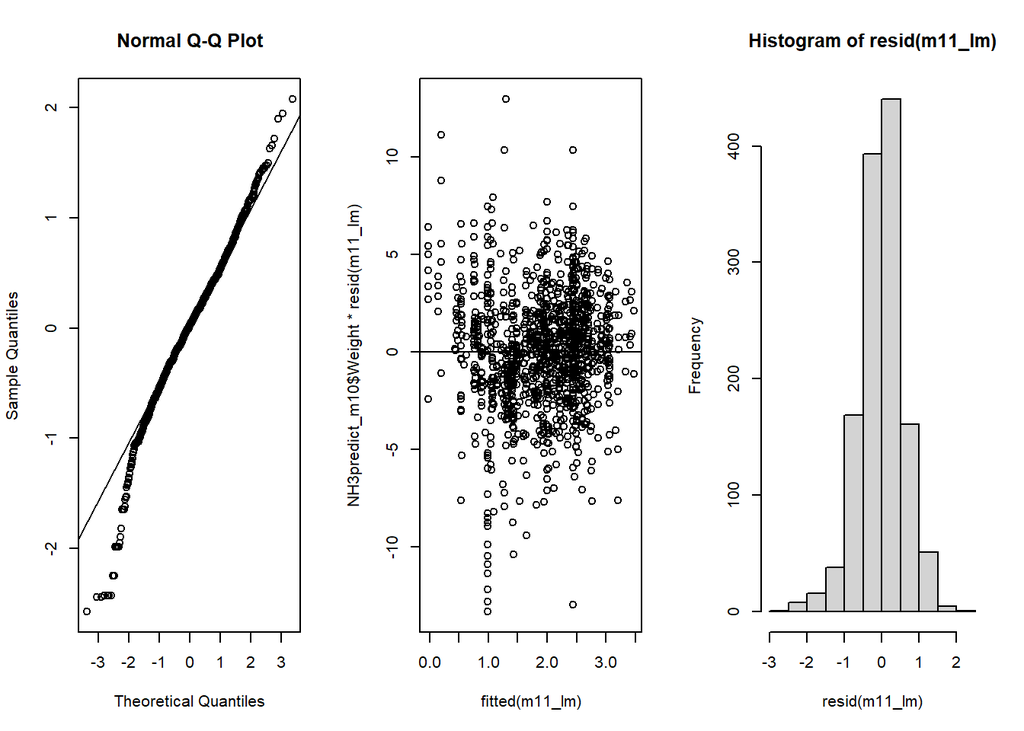

There was no effect of duration of the experiment on NH3-loss (F(1, 1281) =0.09, p = 0.768).

```
##
## Call:
## lm(formula = sign(NH3loss) * abs(NH3loss)^(1/3) ~ Duration +
##     offset(M1_fit), data = NH3predict_m11, weights = Weight)
##
## Weighted Residuals:
##     Min      1Q  Median      3Q     Max
## -5.7631 -0.7601  0.0543  0.8255  4.2717
##
## Coefficients:
##               Estimate Std. Error t value Pr(>|t|)
## (Intercept) -0.0077783  0.0276265  -0.282    0.778
## Duration     0.0003175  0.0010776   0.295    0.768
##
## Residual standard error: 1.332 on 1281 degrees of freedom
## Multiple R-squared:  6.777e-05,  Adjusted R-squared:  -0.0007128
## F-statistic: 0.08682 on 1 and 1281 DF,  p-value: 0.7683
```

```
## Analysis of Variance Table
##
## Response: sign(NH3loss) * abs(NH3loss)^(1/3)
##             Df  Sum Sq Mean Sq F value Pr(>F)
## Duration     1    0.15 0.15407  0.0868 0.7683
## Residuals 1281 2273.33 1.77465
```

Adjusted R2-value of the model was -7.1^{-4}, and multiple R2 was 7^{-5}. The negative adjusted R2-value indicates that the amount of variation accounted for by duration of the experiment is negligible. In practice, it explain no variation in the data.

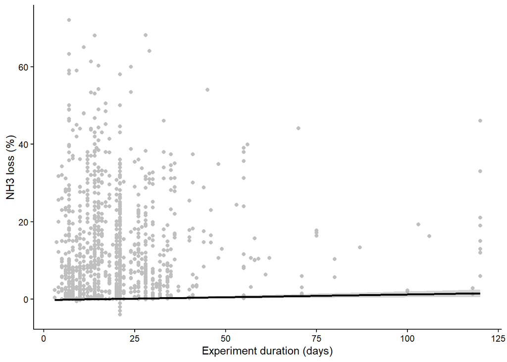

## Combined model with all variables of effect

### Model LO1_Base model and pH

```
## Type III Analysis of Variance Table with Satterthwaite's method
##                   Sum Sq Mean Sq NumDF   DenDF  F value    Pr(>F)
## Fertiliser        586.60 195.532     3 1301.65 105.7393 < 2.2e-16 ***
## Application        76.64  25.548     3 1224.96  13.8157 7.288e-09 ***
## Method             38.89   6.482     6  219.65   3.5055  0.002482 **
## pH_cat             58.84  58.840     1 1257.59  31.8194 2.088e-08 ***
## Fertiliser:pH_cat 126.01  42.003     3 1300.87  22.7145 2.463e-14 ***
## ---
## Signif. codes:  0 '***' 0.001 '**' 0.01 '*' 0.05 '.' 0.1 ' ' 1
```

```
## Linear mixed model fit by REML. t-tests use Satterthwaite's method [
## lmerModLmerTest]
## Formula: sign(NH3loss) * abs(NH3loss)^(1/3) ~ Fertiliser + Application +
##     Method + pH_cat + Fertiliser:pH_cat + (1 | Ref)
##    Data: NH3predict_mALL
## Weights: Weight
## Control: lmerControl(optimizer = "bobyqa")
##
## REML criterion at convergence: 2838.6
##
## Scaled residuals:
##     Min      1Q  Median      3Q     Max
## -4.2400 -0.5021  0.0225  0.5648  3.1867
##
## Random effects:
##  Groups   Name        Variance Std.Dev.
##  Ref      (Intercept) 0.3444   0.5869
##  Residual             1.8492   1.3598
## Number of obs: 1355, groups:  Ref, 157
##
## Fixed effects:
##                                     Estimate Std. Error         df t value
## (Intercept)                          2.49182    0.11262  278.17267  22.125
## FertiliserUAN                       -0.50264    0.14983 1328.93111  -3.355
## Fertiliserammonium+1                -1.07336    0.10049 1321.59436 -10.681
## Fertiliserammonium+2                -1.51796    0.06861 1244.44726 -22.123
## ApplicationIncorporated             -0.53016    0.08985 1279.65692  -5.901
## ApplicationInjected                 -0.60972    0.21500 1323.75552  -2.836
## ApplicationLiquid                   -0.09985    0.11740 1094.73567  -0.851
## Method15N                           -0.29200    0.35739 1183.82516  -0.817
## MethodClosed chamber                -0.33495    0.15081  182.33653  -2.221
## MethodDrager-Tube                   -0.55108    0.23715  131.54017  -2.324
## MethodSemi-open                      0.05284    0.17228  174.55311   0.307
## MethodVentilated chambers           -0.31170    0.13382  437.07822  -2.329
## MethodWindtunnel                     0.23075    0.16779  258.41392   1.375
## pH_catchalky                        -0.04230    0.07540 1078.93129  -0.561
## FertiliserUAN:pH_catchalky           0.43902    0.17036 1315.67925   2.577
## Fertiliserammonium+1:pH_catchalky    1.20305    0.15025 1311.45958   8.007
## Fertiliserammonium+2:pH_catchalky    0.42835    0.14518 1286.45582   2.950
##                                   Pr(>|t|)
## (Intercept)                        < 2e-16 ***
## FertiliserUAN                     0.000816 ***
## Fertiliserammonium+1               < 2e-16 ***
## Fertiliserammonium+2               < 2e-16 ***
## ApplicationIncorporated           4.63e-09 ***
## ApplicationInjected               0.004639 **
## ApplicationLiquid                 0.395212
## Method15N                         0.414073
## MethodClosed chamber              0.027581 *
## MethodDrager-Tube                 0.021672 *
## MethodSemi-open                   0.759411
## MethodVentilated chambers         0.020301 *
## MethodWindtunnel                  0.170241
## pH_catchalky                      0.574892
## FertiliserUAN:pH_catchalky        0.010072 *
## Fertiliserammonium+1:pH_catchalky 2.58e-15 ***
## Fertiliserammonium+2:pH_catchalky 0.003231 **
## ---
## Signif. codes:  0 '***' 0.001 '**' 0.01 '*' 0.05 '.' 0.1 ' ' 1
```

```
##
## Correlation matrix not shown by default, as p = 17 > 12.
## Use print(x, correlation=TRUE)  or
##     vcov(x)        if you need it
```

```
##            R2m       R2c
## [1,] 0.1303847 0.2669278
```

Total observations = 1355

Model LO1 explains 26.69 % of the variation in the data (conditional R2), with the fixed effects explaining 13.04 % (marginal R2). The R2-values for linear mixed effects model were calculated according to Nagakawa & Schielzeth (2013).

```
##                Factor               Level    Effect        SE         df
## 1          Fertiliser               urea+ 2.4918239 0.1130307   939.7916
## 2          Fertiliser                 UAN 1.9891809 0.1856163  3183.7285
## 3          Fertiliser          ammonium+1 1.4184634 0.1471911  2159.8479
## 4          Fertiliser          ammonium+2 0.9738657 0.1294519  1454.5726
## 5         Application           Broadcast 2.4918239 0.1130307   939.7916
## 6         Application        Incorporated 1.9616641 0.1412556  1708.0797
## 7         Application            Injected 1.8821073 0.2443845  8932.7613
## 8         Application              Liquid 2.3919744 0.1546344  1595.2169
## 9              Method            Micromet 2.4918239 0.1130307   939.7916
## 10             Method                 15N 2.1998263 0.3419296 12351.0785
## 11             Method      Closed chamber 2.1568699 0.1092440   343.2532
## 12             Method         Drager-Tube 1.9407431 0.2178561   159.6628
## 13             Method           Semi-open 2.5446680 0.1336188   483.3002
## 14             Method Ventilated chambers 2.1801203 0.1090406   604.9953
```

[output cut: 37 more lines]

### Model LO2_Base model, pH, and Application rate

```
## Type III Analysis of Variance Table with Satterthwaite's method
##                   Sum Sq Mean Sq NumDF  DenDF F value    Pr(>F)
## Fertiliser        500.68 166.892     3 1255.4 90.1447 < 2.2e-16 ***
## Application        77.48  25.826     3 1157.4 13.9496 6.144e-09 ***
## Method             39.94   6.657     6  214.6  3.5958  0.002036 **
## pH_cat             55.18  55.185     1 1246.5 29.8074 5.753e-08 ***
## Application.rate   25.38  25.378     1 1025.0 13.7077  0.000225 ***
## Fertiliser:pH_cat 117.92  39.307     3 1265.6 21.2311 2.024e-13 ***
## ---
## Signif. codes:  0 '***' 0.001 '**' 0.01 '*' 0.05 '.' 0.1 ' ' 1
```

```
## Linear mixed model fit by REML. t-tests use Satterthwaite's method [
## lmerModLmerTest]
## Formula: sign(NH3loss) * abs(NH3loss)^(1/3) ~ Fertiliser + Application +
##     Method + pH_cat + Fertiliser:pH_cat + Application.rate +      (1 | Ref)
##    Data: NH3predict_mALL2
## Weights: Weight
## Control: lmerControl(optimizer = "bobyqa")
##
## REML criterion at convergence: 2779.4
##
## Scaled residuals:
##     Min      1Q  Median      3Q     Max
## -4.3711 -0.5034  0.0283  0.5628  3.0407
##
## Random effects:
##  Groups   Name        Variance Std.Dev.
##  Ref      (Intercept) 0.3628   0.6023
##  Residual             1.8514   1.3607
## Number of obs: 1317, groups:  Ref, 152
##
## Fixed effects:
##                                     Estimate Std. Error         df t value
## (Intercept)                        2.290e+00  1.286e-01  3.149e+02  17.806
## FertiliserUAN                     -5.095e-01  1.549e-01  1.278e+03  -3.290
## Fertiliserammonium+1              -1.044e+00  1.036e-01  1.283e+03 -10.084
## Fertiliserammonium+2              -1.516e+00  6.947e-02  1.203e+03 -21.824
## ApplicationIncorporated           -5.468e-01  9.197e-02  1.264e+03  -5.946
## ApplicationInjected               -6.128e-01  2.165e-01  1.284e+03  -2.830
## ApplicationLiquid                 -7.488e-02  1.288e-01  9.584e+02  -0.581
## Method15N                         -3.189e-01  3.601e-01  1.127e+03  -0.886
## MethodClosed chamber              -3.839e-01  1.565e-01  1.736e+02  -2.454
## MethodDrager-Tube                 -5.071e-01  2.432e-01  1.267e+02  -2.085
## MethodSemi-open                    4.540e-02  1.766e-01  1.676e+02   0.257
## MethodVentilated chambers         -3.392e-01  1.369e-01  4.373e+02  -2.479
## MethodWindtunnel                   2.235e-01  1.710e-01  2.532e+02   1.307
## pH_catchalky                      -4.690e-02  7.701e-02  1.087e+03  -0.609
## Application.rate                   1.790e-03  4.833e-04  1.025e+03   3.702
## FertiliserUAN:pH_catchalky         4.458e-01  1.765e-01  1.275e+03   2.525
## Fertiliserammonium+1:pH_catchalky  1.189e+00  1.531e-01  1.273e+03   7.770
## Fertiliserammonium+2:pH_catchalky  4.321e-01  1.565e-01  1.259e+03   2.760
##                                   Pr(>|t|)
## (Intercept)                        < 2e-16 ***
## FertiliserUAN                     0.001030 **
## Fertiliserammonium+1               < 2e-16 ***
## Fertiliserammonium+2               < 2e-16 ***
## ApplicationIncorporated           3.55e-09 ***
## ApplicationInjected               0.004723 **
## ApplicationLiquid                 0.561202
## Method15N                         0.375990
## MethodClosed chamber              0.015126 *
## MethodDrager-Tube                 0.039111 *
## MethodSemi-open                   0.797377
## MethodVentilated chambers         0.013566 *
## MethodWindtunnel                  0.192500
## pH_catchalky                      0.542684
## Application.rate                  0.000225 ***
## FertiliserUAN:pH_catchalky        0.011675 *
## Fertiliserammonium+1:pH_catchalky 1.61e-14 ***
## Fertiliserammonium+2:pH_catchalky 0.005859 **
## ---
## Signif. codes:  0 '***' 0.001 '**' 0.01 '*' 0.05 '.' 0.1 ' ' 1
```

```
##
## Correlation matrix not shown by default, as p = 18 > 12.
## Use print(x, correlation=TRUE)  or
##     vcov(x)        if you need it
```

```
##            R2m      R2c
## [1,] 0.1378946 0.279151
```

Model LO2 explains 27.92 % of the variation in the data (conditional R2), with the fixed effects explaining 13.79 % (marginal R2). Total observations = 1317

### Model LO3_Base model, pH and temperature

```
## Type III Analysis of Variance Table with Satterthwaite's method
##                   Sum Sq Mean Sq NumDF   DenDF F value    Pr(>F)
## Fertiliser        358.97 119.656     3 1008.51 63.5924 < 2.2e-16 ***
## Application        69.46  23.153     3  936.71 12.3048 6.712e-08 ***
## Method             66.64  11.107     6  170.21  5.9031 1.281e-05 ***
## pH_cat             39.51  39.512     1  977.50 20.9990 5.190e-06 ***
## AirTemperature     44.46  44.459     1  900.54 23.6284 1.378e-06 ***
## Fertiliser:pH_cat  53.85  17.949     3 1007.38  9.5394 3.245e-06 ***
## ---
## Signif. codes:  0 '***' 0.001 '**' 0.01 '*' 0.05 '.' 0.1 ' ' 1
```

```
## Linear mixed model fit by REML. t-tests use Satterthwaite's method [
## lmerModLmerTest]
## Formula: sign(NH3loss) * abs(NH3loss)^(1/3) ~ Fertiliser + Application +
##     Method + pH_cat + Fertiliser:pH_cat + AirTemperature + (1 |      Ref)
##    Data: NH3predict_mALL3
## Weights: Weight
## Control: lmerControl(optimizer = "bobyqa")
##
## REML criterion at convergence: 2186.1
##
## Scaled residuals:
##     Min      1Q  Median      3Q     Max
## -4.1954 -0.5007  0.0272  0.5698  3.1415
##
## Random effects:
##  Groups   Name        Variance Std.Dev.
##  Ref      (Intercept) 0.296    0.5441
##  Residual             1.882    1.3717
## Number of obs: 1034, groups:  Ref, 116
##
## Fixed effects:
##                                     Estimate Std. Error         df t value
## (Intercept)                        2.172e+00  1.364e-01  2.511e+02  15.917
## FertiliserUAN                     -5.692e-01  1.615e-01  1.010e+03  -3.525
## Fertiliserammonium+1              -8.755e-01  1.262e-01  1.016e+03  -6.939
## Fertiliserammonium+2              -1.486e+00  7.389e-02  9.550e+02 -20.114
## ApplicationIncorporated           -5.496e-01  1.005e-01  9.950e+02  -5.471
## ApplicationInjected               -5.833e-01  2.189e-01  1.008e+03  -2.665
## ApplicationLiquid                  4.489e-02  1.375e-01  8.396e+02   0.327
## Method15N                          2.134e-02  3.935e-01  9.413e+02   0.054
## MethodClosed chamber              -3.977e-01  1.720e-01  1.332e+02  -2.312
## MethodDrager-Tube                 -7.623e-01  2.417e-01  1.022e+02  -3.155
## MethodSemi-open                   -8.284e-02  1.893e-01  1.421e+02  -0.438
## MethodVentilated chambers         -5.877e-01  1.496e-01  3.381e+02  -3.928
## MethodWindtunnel                   2.142e-01  1.705e-01  2.009e+02   1.256
## pH_catchalky                      -3.164e-02  8.272e-02  8.632e+02  -0.382
## AirTemperature                     2.143e-02  4.408e-03  9.005e+02   4.861
## FertiliserUAN:pH_catchalky         5.304e-01  1.889e-01  1.006e+03   2.808
## Fertiliserammonium+1:pH_catchalky  8.977e-01  1.989e-01  1.016e+03   4.512
## Fertiliserammonium+2:pH_catchalky  4.244e-01  1.853e-01  1.009e+03   2.291
##                                   Pr(>|t|)
## (Intercept)                        < 2e-16 ***
## FertiliserUAN                     0.000443 ***
## Fertiliserammonium+1              7.04e-12 ***
## Fertiliserammonium+2               < 2e-16 ***
## ApplicationIncorporated           5.67e-08 ***
## ApplicationInjected               0.007827 **
## ApplicationLiquid                 0.744085
## Method15N                         0.956768
## MethodClosed chamber              0.022330 *
## MethodDrager-Tube                 0.002111 **
## MethodSemi-open                   0.662289
## MethodVentilated chambers         0.000104 ***
## MethodWindtunnel                  0.210500
## pH_catchalky                      0.702199
## AirTemperature                    1.38e-06 ***
## FertiliserUAN:pH_catchalky        0.005079 **
## Fertiliserammonium+1:pH_catchalky 7.16e-06 ***
## Fertiliserammonium+2:pH_catchalky 0.022189 *
## ---
## Signif. codes:  0 '***' 0.001 '**' 0.01 '*' 0.05 '.' 0.1 ' ' 1
```

```
##
## Correlation matrix not shown by default, as p = 18 > 12.
## Use print(x, correlation=TRUE)  or
##     vcov(x)        if you need it
```

```
##            R2m       R2c
## [1,] 0.1471101 0.2630527
```

Total observations = 1034

Model LO3 explains 26.31 % of the variation in the data (conditional R2), with the fixed effects explaining 14.71 % (marginal R2). The R2-values for linear mixed effects model were calculated according to Nagakawa & Schielzeth (2013).

### Model LO4_Base variables, pH, application rate, and temperature

```r
mALL4_lmer <- lmer(sign(NH3loss) * abs(NH3loss) ^ (1/3) ~ Fertiliser + Application + Method  +
                    pH_cat + Fertiliser:pH_cat +
                    Application.rate + AirTemperature +
                    (1|Ref),
                   weights=Weight,
                   control=lmerControl(optimizer="bobyqa"),
                   data=NH3predict_mALL4)
```

Total observations = 1025

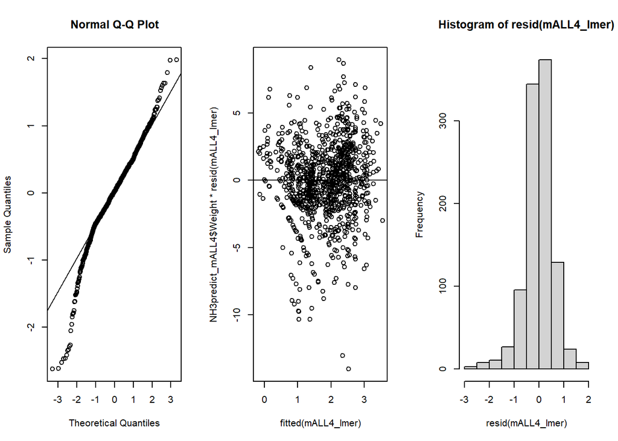

```
## Type III Analysis of Variance Table with Satterthwaite's method
##                   Sum Sq Mean Sq NumDF  DenDF F value    Pr(>F)
## Fertiliser        350.64 116.882     3 999.09 62.7842 < 2.2e-16 ***
## Application        70.87  23.623     3 938.90 12.6896 3.904e-08 ***
## Method             64.81  10.802     6 167.00  5.8022 1.637e-05 ***
## pH_cat             35.57  35.566     1 976.02 19.1045 1.370e-05 ***
## Application.rate   19.43  19.431     1 578.24 10.4375  0.001305 **
## AirTemperature     38.73  38.735     1 908.91 20.8069 5.776e-06 ***
## Fertiliser:pH_cat  46.55  15.516     3 995.97  8.3343 1.778e-05 ***
## ---
## Signif. codes:  0 '***' 0.001 '**' 0.01 '*' 0.05 '.' 0.1 ' ' 1
```

```
## Linear mixed model fit by REML. t-tests use Satterthwaite's method [
## lmerModLmerTest]
## Formula: sign(NH3loss) * abs(NH3loss)^(1/3) ~ Fertiliser + Application +
##     Method + pH_cat + Fertiliser:pH_cat + Application.rate +
##     AirTemperature + (1 | Ref)
##    Data: NH3predict_mALL4
## Weights: Weight
## Control: lmerControl(optimizer = "bobyqa")
##
## REML criterion at convergence: 2174.5
##
## Scaled residuals:
##     Min      1Q  Median      3Q     Max
## -4.3671 -0.4966  0.0332  0.5752  2.9861
##
## Random effects:
##  Groups   Name        Variance Std.Dev.
##  Ref      (Intercept) 0.3179   0.5639
##  Residual             1.8616   1.3644
## Number of obs: 1025, groups:  Ref, 114
##
## Fixed effects:
##                                     Estimate Std. Error         df t value
## (Intercept)                        1.961e+00  1.528e-01  2.584e+02  12.832
## FertiliserUAN                     -5.533e-01  1.614e-01  1.004e+03  -3.428
## Fertiliserammonium+1              -8.127e-01  1.317e-01  1.006e+03  -6.170
## Fertiliserammonium+2              -1.484e+00  7.452e-02  9.390e+02 -19.909
## ApplicationIncorporated           -5.572e-01  1.005e-01  9.917e+02  -5.545
## ApplicationInjected               -6.000e-01  2.184e-01  9.952e+02  -2.748
## ApplicationLiquid                  4.089e-02  1.378e-01  8.604e+02   0.297
## Method15N                          4.754e-02  3.940e-01  9.177e+02   0.121
## MethodClosed chamber              -3.906e-01  1.761e-01  1.265e+02  -2.218
## MethodDrager-Tube                 -7.026e-01  2.489e-01  9.804e+01  -2.822
## MethodSemi-open                   -8.367e-02  1.940e-01  1.354e+02  -0.431
## MethodVentilated chambers         -6.301e-01  1.532e-01  3.432e+02  -4.112
## MethodWindtunnel                   2.129e-01  1.736e-01  1.970e+02   1.226
## pH_catchalky                      -2.796e-02  8.324e-02  8.800e+02  -0.336
## Application.rate                   1.972e-03  6.103e-04  5.782e+02   3.231
## AirTemperature                     2.022e-02  4.433e-03  9.089e+02   4.561
## FertiliserUAN:pH_catchalky         5.177e-01  1.884e-01  9.937e+02   2.748
```

[output cut: 9 more lines]

```
## ApplicationLiquid                 0.766778
## Method15N                         0.903974
## MethodClosed chamber              0.028360 *
## MethodDrager-Tube                 0.005773 **
## MethodSemi-open                   0.666895
## MethodVentilated chambers         4.91e-05 ***
## MethodWindtunnel                  0.221504
## pH_catchalky                      0.736994
## Application.rate                  0.001305 **
## AirTemperature                    5.78e-06 ***
## FertiliserUAN:pH_catchalky        0.006114 **
## Fertiliserammonium+1:pH_catchalky 4.84e-05 ***
## Fertiliserammonium+2:pH_catchalky 0.022230 *
## ---
## Signif. codes:  0 '***' 0.001 '**' 0.01 '*' 0.05 '.' 0.1 ' ' 1
```

```
##
## Correlation matrix not shown by default, as p = 19 > 12.
## Use print(x, correlation=TRUE)  or
##     vcov(x)        if you need it
```

```
##            R2m      R2c
## [1,] 0.1550775 0.278326
```

Model LO4 explains 27.83 % of the variation in the data (conditional R2), with the fixed effects explaining 15.51 % (marginal R2).

```
##                Factor               Level   Effect        SE        df
## 1          Fertiliser               urea+ 2.504811 0.1252218  738.2512
## 2          Fertiliser                 UAN 1.951502 0.1998260 2522.4874
## 3          Fertiliser          ammonium+1 1.692145 0.1765556 2066.5781
## 4          Fertiliser          ammonium+2 1.021117 0.1421265 1082.7927
## 5         Application           Broadcast 2.504811 0.1252218  738.2512
## 6         Application        Incorporated 1.947616 0.1592969 1452.8852
## 7         Application            Injected 1.904801 0.2544333 6108.5191
## 8         Application              Liquid 2.545705 0.1792059 1332.2587
## 9              Method            Micromet 2.504811 0.1252218  738.2512
## 10             Method                 15N 2.552354 0.3765228 6620.2887
## 11             Method      Closed chamber 2.114215 0.1334390  218.6295
## 12             Method         Drager-Tube 1.802252 0.2263767  120.4304
## 13             Method           Semi-open 2.421145 0.1509920  431.8876
## 14             Method Ventilated chambers 1.874679 0.1312994  419.7120
```

[output cut: 37 more lines]

The same effect sizes (and their 95% confidence interval) are shown below:

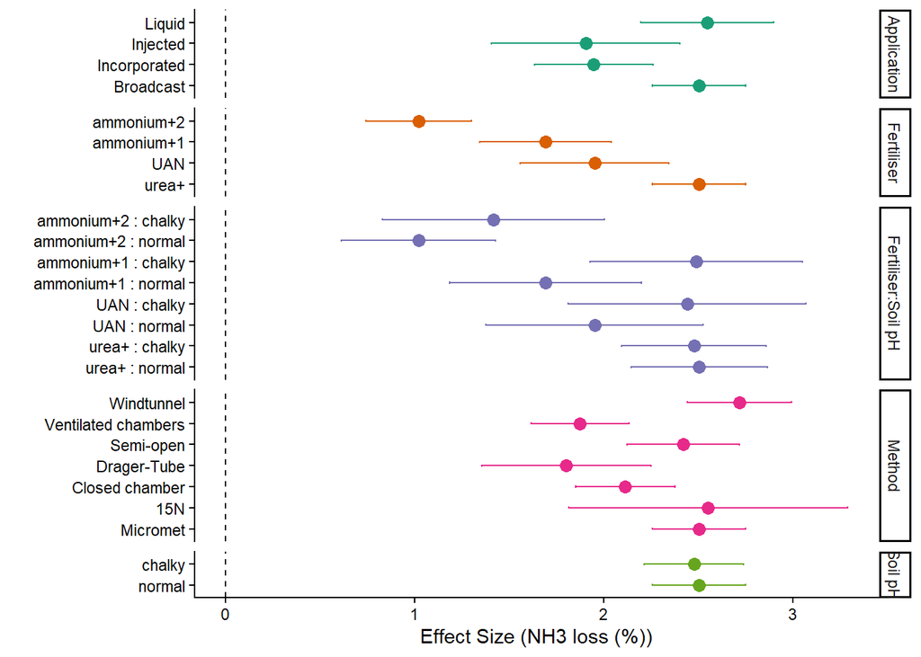

### Model LO5_Base model, pH, temperature, rainfall and Application rate

```
## Type III Analysis of Variance Table with Satterthwaite's method
##                          Sum Sq Mean Sq NumDF  DenDF F value    Pr(>F)
## Fertiliser               340.41 113.470     3 888.21 59.2272 < 2.2e-16 ***
## Application               40.53  13.510     3 837.69  7.0515 0.0001102 ***
## Method                    47.94   7.990     6 137.42  4.1705 0.0006970 ***
## pH_cat                    30.51  30.507     1 899.18 15.9239 7.131e-05 ***
## Application.rate          21.56  21.562     1 700.86 11.2545 0.0008371 ***
## AirTemperature            16.15  16.152     1 838.76  8.4306 0.0037865 **
## Rain.mean                 14.49  14.488     1 871.87  7.5621 0.0060841 **
## Fertiliser:pH_cat         37.70  12.568     3 886.97  6.5599 0.0002180 ***
## AirTemperature:Rain.mean   6.88   6.877     1 871.34  3.5896 0.0584728 .
## ---
## Signif. codes:  0 '***' 0.001 '**' 0.01 '*' 0.05 '.' 0.1 ' ' 1
```

```
## Linear mixed model fit by REML. t-tests use Satterthwaite's method [
## lmerModLmerTest]
## Formula: sign(NH3loss) * abs(NH3loss)^(1/3) ~ Fertiliser + Application +
##     Method + pH_cat + Fertiliser:pH_cat + Application.rate +
##     AirTemperature + Rain.mean + AirTemperature * Rain.mean +      (1 | Ref)
##    Data: NH3predict_mALL5
## Weights: Weight
## Control: lmerControl(optimizer = "bobyqa")
##
## REML criterion at convergence: 1999.2
##
## Scaled residuals:
##     Min      1Q  Median      3Q     Max
## -4.1556 -0.4860  0.0340  0.5776  2.9306
##
## Random effects:
##  Groups   Name        Variance Std.Dev.
##  Ref      (Intercept) 0.305    0.5523
##  Residual             1.916    1.3841
## Number of obs: 923, groups:  Ref, 99
##
## Fixed effects:
##                                     Estimate Std. Error         df t value
## (Intercept)                        2.015e+00  1.719e-01  2.519e+02  11.722
## FertiliserUAN                     -4.915e-01  1.810e-01  9.004e+02  -2.716
## Fertiliserammonium+1              -8.366e-01  1.690e-01  8.898e+02  -4.951
## Fertiliserammonium+2              -1.477e+00  7.668e-02  8.482e+02 -19.258
## ApplicationIncorporated           -4.553e-01  1.099e-01  8.704e+02  -4.144
## ApplicationInjected               -6.743e-01  3.287e-01  8.759e+02  -2.052
## ApplicationLiquid                  7.423e-03  1.488e-01  7.993e+02   0.050
## Method15N                          1.137e-01  4.020e-01  7.748e+02   0.283
## MethodClosed chamber              -3.226e-01  1.854e-01  9.982e+01  -1.740
## MethodDrager-Tube                 -6.003e-01  2.505e-01  8.531e+01  -2.397
## MethodSemi-open                   -2.485e-03  2.064e-01  1.181e+02  -0.012
## MethodVentilated chambers         -6.259e-01  1.892e-01  2.020e+02  -3.308
## MethodWindtunnel                   2.208e-01  1.894e-01  1.535e+02   1.166
## pH_catchalky                      -2.143e-02  8.697e-02  8.155e+02  -0.246
## Application.rate                   2.331e-03  6.947e-04  7.009e+02   3.355
## AirTemperature                     1.602e-02  5.519e-03  8.388e+02   2.904
## Rain.mean                         -1.005e-01  3.656e-02  8.719e+02  -2.750
```

[output cut: 13 more lines]

```
## MethodClosed chamber              0.085019 .
## MethodDrager-Tube                 0.018729 *
## MethodSemi-open                   0.990411
## MethodVentilated chambers         0.001111 **
## MethodWindtunnel                  0.245411
## pH_catchalky                      0.805409
## Application.rate                  0.000837 ***
## AirTemperature                    0.003786 **
## Rain.mean                         0.006084 **
## FertiliserUAN:pH_catchalky        0.012257 *
## Fertiliserammonium+1:pH_catchalky 0.000625 ***
## Fertiliserammonium+2:pH_catchalky 0.025857 *
## AirTemperature:Rain.mean          0.058473 .
## ---
## Signif. codes:  0 '***' 0.001 '**' 0.01 '*' 0.05 '.' 0.1 ' ' 1
```

```
##
## Correlation matrix not shown by default, as p = 21 > 12.
## Use print(x, correlation=TRUE)  or
##     vcov(x)        if you need it
```

```
##            R2m       R2c
## [1,] 0.1512051 0.2677911
```

Model LO5 explains 26.78 % of the variation in the data (conditional R2), with the fixed effects explaining 15.12 % (marginal R2). Total observations = 923

### Model LO6_Base model, pH, temperature, non-linear rainfall and Application rate

```
## Type III Analysis of Variance Table with Satterthwaite's method
##                         Sum Sq Mean Sq NumDF  DenDF F value    Pr(>F)
## Fertiliser              340.79 113.595     3 888.20 59.3116 < 2.2e-16 ***
## Application              40.66  13.552     3 837.77  7.0761 0.0001065 ***
## Method                   48.29   8.048     6 137.28  4.2019 0.0006516 ***
## pH_cat                   30.55  30.548     1 899.27 15.9503 7.034e-05 ***
## Application.rate         21.80  21.801     1 701.13 11.3828 0.0007821 ***
## AirTemperature           10.10  10.104     1 872.30  5.2759 0.0218593 *
## Rain.exp                 14.84  14.836     1 876.57  7.7462 0.0054984 **
## Fertiliser:pH_cat        37.48  12.495     3 886.92  6.5238 0.0002293 ***
## AirTemperature:Rain.exp   6.84   6.836     1 877.38  3.5694 0.0591845 .
## ---
## Signif. codes:  0 '***' 0.001 '**' 0.01 '*' 0.05 '.' 0.1 ' ' 1
```

```
## Linear mixed model fit by REML. t-tests use Satterthwaite's method [
## lmerModLmerTest]
## Formula: sign(NH3loss) * abs(NH3loss)^(1/3) ~ Fertiliser + Application +
##     Method + pH_cat + Fertiliser:pH_cat + Application.rate +
##     AirTemperature + Rain.exp + AirTemperature * Rain.exp + (1 |      Ref)
##    Data: NH3predict_mALL6
## Weights: Weight
## Control: lmerControl(optimizer = "bobyqa")
##
## REML criterion at convergence: 1994.6
##
## Scaled residuals:
##     Min      1Q  Median      3Q     Max
## -4.1514 -0.4879  0.0385  0.5811  2.9353
##
## Random effects:
##  Groups   Name        Variance Std.Dev.
##  Ref      (Intercept) 0.3049   0.5522
##  Residual             1.9152   1.3839
## Number of obs: 923, groups:  Ref, 99
##
## Fixed effects:
##                                     Estimate Std. Error         df t value
## (Intercept)                       -1.365e+00  1.166e+00  8.745e+02  -1.171
## FertiliserUAN                     -3.299e-03  1.938e-01  9.020e+02  -0.017
## Fertiliserammonium+1              -2.540e-02  1.673e-01  8.526e+02  -0.152
## Fertiliserammonium+2              -1.056e+00  1.759e-01  9.000e+02  -6.005
## ApplicationIncorporated           -4.563e-01  1.098e-01  8.705e+02  -4.155
## ApplicationInjected               -6.747e-01  3.286e-01  8.758e+02  -2.053
## ApplicationLiquid                  6.196e-03  1.488e-01  7.994e+02   0.042
## Method15N                          1.159e-01  4.019e-01  7.748e+02   0.288
## MethodClosed chamber              -3.208e-01  1.854e-01  9.974e+01  -1.730
## MethodDrager-Tube                 -5.992e-01  2.505e-01  8.525e+01  -2.392
## MethodSemi-open                    2.563e-04  2.063e-01  1.181e+02   0.001
## MethodVentilated chambers         -6.314e-01  1.891e-01  2.015e+02  -3.340
## MethodWindtunnel                   2.194e-01  1.894e-01  1.536e+02   1.158
## pH_catnormal                       1.987e-02  8.694e-02  8.155e+02   0.229
## Application.rate                   2.344e-03  6.948e-04  7.011e+02   3.374
## AirTemperature                     1.156e-01  5.034e-02  8.723e+02   2.297
## Rain.exp                           2.914e-01  1.047e-01  8.766e+02   2.783
```

[output cut: 13 more lines]

```
## MethodClosed chamber              0.086682 .
## MethodDrager-Tube                 0.018943 *
## MethodSemi-open                   0.999011
## MethodVentilated chambers         0.001000 ***
## MethodWindtunnel                  0.248462
## pH_catnormal                      0.819251
## Application.rate                  0.000782 ***
## AirTemperature                    0.021859 *
## Rain.exp                          0.005498 **
## FertiliserUAN:pH_catnormal        0.012586 *
## Fertiliserammonium+1:pH_catnormal 0.000639 ***
## Fertiliserammonium+2:pH_catnormal 0.026499 *
## AirTemperature:Rain.exp           0.059184 .
## ---
## Signif. codes:  0 '***' 0.001 '**' 0.01 '*' 0.05 '.' 0.1 ' ' 1
```

```
##
## Correlation matrix not shown by default, as p = 21 > 12.
## Use print(x, correlation=TRUE)  or
##     vcov(x)        if you need it
```

# GLMM

```
## Analysis of Deviance Table (Type II Wald chisquare tests)
##
## Response: NH3loss
##                     Chisq Df Pr(>Chisq)
## Fertiliser        257.242  3  < 2.2e-16 ***
## Application        39.461  3  1.386e-08 ***
## Method             36.231  6  2.486e-06 ***
## pH_cat              6.059  1    0.01384 *
## Clay                2.212  1    0.13694
## AirTemperature     56.362  1  6.029e-14 ***
## Fertiliser:pH_cat  57.358  3  2.155e-12 ***
## ---
## Signif. codes:  0 '***' 0.001 '**' 0.01 '*' 0.05 '.' 0.1 ' ' 1
```

```
##  Family: tweedie  ( log )
## Formula:
## NH3loss ~ Fertiliser + Application + Method + pH_cat + Fertiliser:pH_cat +
##     Clay + AirTemperature + (1 | Ref)
## Dispersion:               ~Fertiliser + Application + Method + pH_cat
## Data: NH3predict_mALL
##
##       AIC       BIC    logLik -2*log(L)  df.resid
##    5541.4    5709.8   -2735.7    5471.4       873
##
## Random effects:
##
## Conditional model:
##  Groups Name        Variance Std.Dev.
##  Ref    (Intercept) 0.6928   0.8323
## Number of obs: 908, groups:  Ref, 99
##
## Conditional model:
##                                    Estimate Std. Error z value Pr(>|z|)
## (Intercept)                        2.415430   0.199280  12.121  < 2e-16 ***
## FertiliserUAN                     -0.626518   0.153402  -4.084 4.42e-05 ***
## Fertiliserammonium+1              -1.350686   0.165554  -8.159 3.39e-16 ***
## Fertiliserammonium+2              -1.937830   0.126638 -15.302  < 2e-16 ***
## ApplicationIncorporated           -0.687749   0.171054  -4.021 5.80e-05 ***
## ApplicationInjected               -0.992816   0.202696  -4.898 9.68e-07 ***
## ApplicationLiquid                 -0.143835   0.125416  -1.147  0.25144
## Method15N                         -0.557094   0.365691  -1.523  0.12766
## MethodClosed chamber              -0.705281   0.264175  -2.670  0.00759 **
## MethodDrager-Tube                 -1.047810   0.402261  -2.605  0.00919 **
## MethodSemi-open                   -0.169074   0.287005  -0.589  0.55580
## MethodVentilated chambers         -0.961922   0.204056  -4.714 2.43e-06 ***
## MethodWindtunnel                   0.248482   0.244794   1.015  0.31007
## pH_catchalky                      -0.046374   0.107936  -0.430  0.66745
## Clay                              -0.004922   0.003309  -1.487  0.13694
## AirTemperature                     0.036594   0.004874   7.507 6.03e-14 ***
## FertiliserUAN:pH_catchalky         0.720810   0.177690   4.057 4.98e-05 ***
## Fertiliserammonium+1:pH_catchalky  1.409253   0.241937   5.825 5.72e-09 ***
## Fertiliserammonium+2:pH_catchalky  1.076836   0.246371   4.371 1.24e-05 ***
## ---
## Signif. codes:  0 '***' 0.001 '**' 0.01 '*' 0.05 '.' 0.1 ' ' 1
##
## Dispersion model:
##                           Estimate Std. Error z value Pr(>|z|)
## (Intercept)                0.47821    0.14802   3.231 0.001235 **
## FertiliserUAN              0.93960    0.25354   3.706 0.000211 ***
## Fertiliserammonium+1      -0.31872    0.17431  -1.828 0.067476 .
## Fertiliserammonium+2       0.46263    0.13267   3.487 0.000489 ***
## ApplicationIncorporated    0.38863    0.14582   2.665 0.007694 **
## ApplicationInjected       -1.05778    0.45369  -2.331 0.019728 *
## ApplicationLiquid         -1.62844    0.19377  -8.404  < 2e-16 ***
## Method15N                 -2.39190    0.79168  -3.021 0.002517 **
## MethodClosed chamber      -0.16986    0.15855  -1.071 0.284028
## MethodDrager-Tube         -0.07477    0.18679  -0.400 0.688941
## MethodSemi-open           -0.30882    0.19479  -1.585 0.112879
## MethodVentilated chambers -0.31649    0.16438  -1.925 0.054179 .
## MethodWindtunnel          -0.10296    0.16694  -0.617 0.537401
## pH_catchalky              -0.04040    0.09933  -0.407 0.684233
## ---
## Signif. codes:  0 '***' 0.001 '**' 0.01 '*' 0.05 '.' 0.1 ' ' 1
```

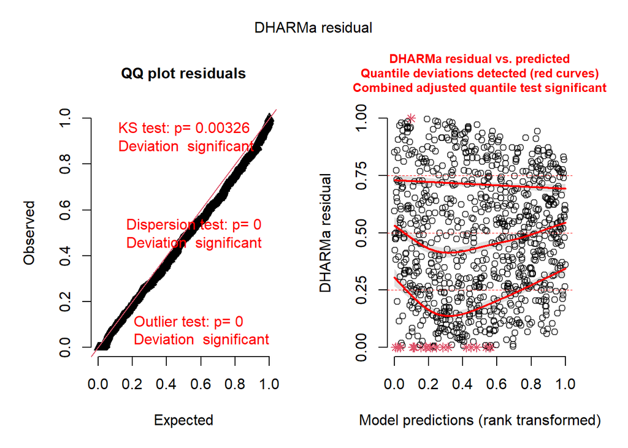

Model LO_GLIMM explains 100 % of the variation in the data (conditional R2), with the fixed effects explaining 50.53 % (marginal R2). The R2-values for linear mixed effects model were calculated according to Nagakawa & Schielzeth (2013).

```
##                Factor               Level    Effect        SE  df  lower.CL
## 1          Fertiliser               urea+ 18.199407 3.1691996 Inf 12.936926
## 2          Fertiliser                 UAN  9.726668 2.2034957 Inf  6.239237
## 3          Fertiliser          ammonium+1  4.714785 1.1112925 Inf  2.970507
## 4          Fertiliser          ammonium+2  2.621008 0.5538349 Inf  1.732225
## 5         Application           Broadcast 18.199407 3.1691996 Inf 12.936926
## 6         Application        Incorporated  9.148960 2.2076292 Inf  5.701356
## 7         Application            Injected  6.743458 1.8253356 Inf  3.967138
## 8         Application              Liquid 15.761250 3.2768109 Inf 10.486325
## 9              Method            Micromet 18.199407 3.1691996 Inf 12.936926
## 10             Method                 15N 10.425915 3.3971748 Inf  5.505023
## 11             Method      Closed chamber  8.989957 1.8650280 Inf  5.986460
## 12             Method         Drager-Tube  6.382623 2.3797213 Inf  3.073506
## 13             Method           Semi-open 15.368423 3.5144602 Inf  9.816937
## 14             Method Ventilated chambers  6.955041 1.2811036 Inf  4.847415
```

[output cut: 37 more lines]

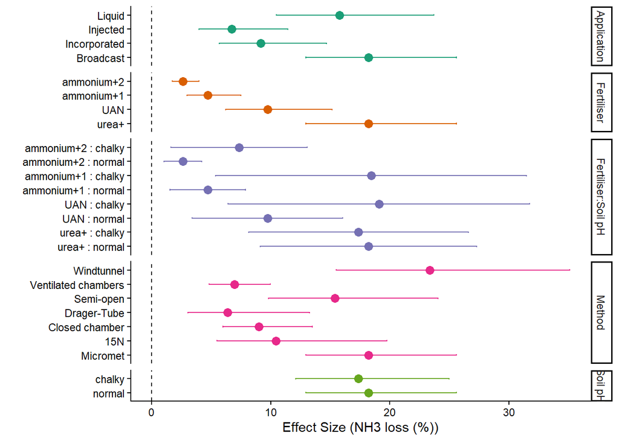

# References

Astivia, Oscar L. Olvera and Zumbo, Bruno D. (2019) “Heteroskedasticity in Multiple Regression Analysis: What it is, How to Detect it and How to Solve it with Applications in R and SPSS,” Practical Assessment, Research, and Evaluation: Vol. 24 , Article 1. DOI: https://doi.org/10.7275/q5xr-fr95

Douglas Bates, Martin Maechler, Ben Bolker, Steve Walker (2015). Fitting Linear Mixed-Effects Models Using lme4. Journal of Statistical Software, 67(1), 1-48. https://doi:10.18637/jss.v067.i01

Nakagawa, S, Schielzeth, H. (2013). A general and simple method for obtaining R^2 from Generalized Linear Mixed-effects Models. Methods in Ecology and Evolution 4: 133-142. https://doi.org/10.1111/j.2041-210x.2012.00261.x